# Taller 1: Regresion Lineal Simple

Bioestadistica Fundamental

Andrés Felipe Florez Rivera

2026-07-09

Universidad Nacional de Colombia — Departamento de Estadistica, Sede Bogota

Este taller tiene dos partes. La **Parte I** presenta las herramientas en R necesarias para realizar un analisis completo de regresion lineal simple por MCO. La **Parte II** plantea el trabajo que los estudiantes deben entregar, aplicando todas las herramientas aprendidas a un nuevo conjunto de datos.

# Parte I: Herramientas en R para Regresion Lineal Simple

Para ilustrar cada herramienta se usa un conjunto de datos simulado con contexto agronomico: precipitacion acumulada durante el ciclo del cultivo (mm) y rendimiento del arroz (t/ha) en 30 lotes experimentales. Los datos se generan de forma reproducible con `set.seed(2024)`.

```r
set.seed(2024)
precipitacion <- round(runif(30, 400, 900), 0)
rendimiento   <- round(2.5 + 0.008 * precipitacion + rnorm(30, 0, 0.4), 2)

datos <- data.frame(precipitacion, rendimiento)

mostrar_tabla(datos, caption = "Precipitacion (mm) y rendimiento de arroz (t/ha)")
```

Precipitacion (mm) y rendimiento de arroz (t/ha)

| precipitacion | rendimiento |
| --- | --- |
| 818 | 8.98 |
| 560 | 6.61 |
| 740 | 8.60 |
| 749 | 7.85 |
| 629 | 6.73 |
| 751 | 8.96 |
| 608 | 7.49 |
| 552 | 7.33 |
| 838 | 9.12 |
| 460 | 6.34 |
| 851 | 8.69 |
| 877 | 9.47 |
| 752 | 8.79 |
| 658 | 6.94 |
| 625 | 7.46 |

Las variables son:

| Variable | Descripcion | Unidad |
| --- | --- | --- |
| `precipitacion` | Precipitacion acumulada durante el ciclo del cultivo | mm |
| `rendimiento` | Rendimiento del arroz | t/ha |

## 1. Exploracion inicial de los datos

Antes de ajustar un modelo de regresion siempre se deben explorar los datos.

### 1.1 Estadisticas descriptivas

```r
summary(datos)
```

```
##  precipitacion    rendimiento
##  Min.   :400.0   Min.   :5.310
##  1st Qu.:546.5   1st Qu.:6.628
##  Median :683.0   Median :7.670
##  Mean   :656.9   Mean   :7.677
##  3rd Qu.:805.8   3rd Qu.:8.850
##  Max.   :877.0   Max.   :9.470
```

### 1.2 Correlacion de Pearson

El coeficiente de correlacion de Pearson mide la fuerza y la direccion de la relacion lineal entre dos variables cuantitativas. Su valor esta entre $-1$ y $1$.

$$r = \frac{\sum_{i=1}^n (X_i - \bar
X)(Y_i - \bar Y)}{\sqrt{\sum_{i=1}^n (X_i-\bar X)^2 \cdot \sum_{i=1}^n
(Y_i-\bar Y)^2}}$$

```r
r <- cor(datos$precipitacion, datos$rendimiento)
cat("Correlacion de Pearson r =", round(r, 4), "\n")
```

```
## Correlacion de Pearson r = 0.9494
```

> Un valor cercano a $1$ indica una relacion lineal positiva fuerte, lo que sugiere que un modelo lineal es apropiado.

### 1.3 Diagrama de dispersion

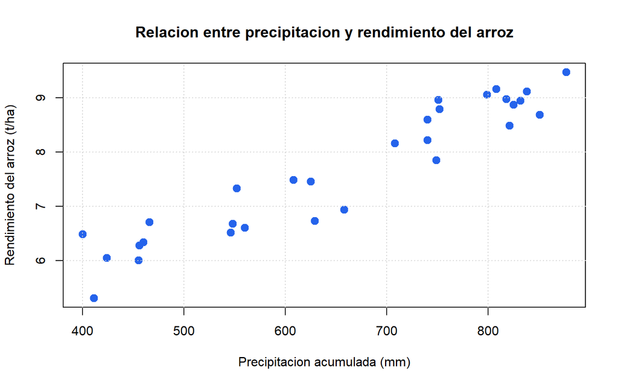

```r
plot(
  rendimiento ~ precipitacion,
  data = datos,
  pch  = 19,
  col  = "#2563eb",
  cex  = 1.3,
  xlab = "Precipitacion acumulada (mm)",
  ylab = "Rendimiento del arroz (t/ha)",
  main = "Relacion entre precipitacion y rendimiento del arroz"
)
grid()
```

> A medida que aumenta la precipitacion, el rendimiento del cultivo tiende a aumentar. La tendencia es aproximadamente lineal y positiva.

## 2. El modelo de regresion lineal simple

El modelo poblacional es:

$$Y_i = \beta_0 + \beta_1 X_i + e_i, \quad
e_i \sim N(0, \sigma^2), \quad i = 1, \ldots, n$$

| Componente | Significado |
| --- | --- |
| $Y_i$ | Valor observado de la variable respuesta |
| $X_i$ | Valor observado de la variable explicativa |
| $\beta_0$ | Intercepto: valor esperado de $Y$ cuando $X = 0$ |
| $\beta_1$ | Pendiente: cambio promedio en $Y$ por cada unidad adicional de $X$ |
| $e_i$ | Error aleatorio asociado a la observacion $i$ |

Cada observacion se descompone en una **parte sistematica** $(\beta_0 + \beta_1 X_i)$ y una **parte aleatoria** $(e_i)$.

## 3. Estimacion por Minimos Cuadrados Ordinarios (MCO)

El criterio MCO consiste en encontrar los valores de $\beta_0$ y $\beta_1$ que minimizan la suma de los errores al cuadrado:

$$\min_{b_0,\, b_1} \sum_{i=1}^{n} e_i^2 =
\min_{b_0,\, b_1} \sum_{i=1}^{n} (y_i - b_0 - b_1 x_i)^2$$

La solucion analitica es:

$$b_1 = \frac{S_{xy}}{S_{xx}} =
\frac{\sum_{i=1}^{n}(X_i - \bar{X})(Y_i - \bar{Y})}{\sum_{i=1}^{n}(X_i -
\bar{X})^2}, \qquad b_0 = \bar{Y} - b_1 \bar{X}$$

### 3.1 Calculo manual paso a paso

```r
xbar <- mean(datos$precipitacion)
ybar <- mean(datos$rendimiento)
n    <- nrow(datos)

tabla_aux <- data.frame(
  X      = datos$precipitacion,
  Y      = datos$rendimiento,
  X_Xbar = datos$precipitacion - xbar,
  Y_Ybar = datos$rendimiento   - ybar
)
tabla_aux$XY <- tabla_aux$X_Xbar * tabla_aux$Y_Ybar
tabla_aux$X2 <- tabla_aux$X_Xbar^2

mostrar_tabla(round(tabla_aux, 4), caption = "Tabla auxiliar para el calculo MCO")
```

Tabla auxiliar para el calculo MCO

| X | Y | X_Xbar | Y_Ybar | XY | X2 |
| --- | --- | --- | --- | --- | --- |
| 818 | 8.98 | 161.1 | 1.3027 | 209.8596 | 25953.21 |
| 560 | 6.61 | -96.9 | -1.0673 | 103.4246 | 9389.61 |
| 740 | 8.60 | 83.1 | 0.9227 | 76.6736 | 6905.61 |
| 749 | 7.85 | 92.1 | 0.1727 | 15.9026 | 8482.41 |
| 629 | 6.73 | -27.9 | -0.9473 | 26.4306 | 778.41 |
| 751 | 8.96 | 94.1 | 1.2827 | 120.6989 | 8854.81 |
| 608 | 7.49 | -48.9 | -0.1873 | 9.1606 | 2391.21 |
| 552 | 7.33 | -104.9 | -0.3473 | 36.4353 | 11004.01 |
| 838 | 9.12 | 181.1 | 1.4427 | 261.2669 | 32797.21 |
| 460 | 6.34 | -196.9 | -1.3373 | 263.3209 | 38769.61 |
| 851 | 8.69 | 194.1 | 1.0127 | 196.5586 | 37674.81 |
| 877 | 9.47 | 220.1 | 1.7927 | 394.5659 | 48444.01 |
| 752 | 8.79 | 95.1 | 1.1127 | 105.8146 | 9044.01 |
| 658 | 6.94 | 1.1 | -0.7373 | -0.8111 | 1.21 |
| 625 | 7.46 | -31.9 | -0.2173 | 6.9329 | 1017.61 |

```r
Sxy <- sum(tabla_aux$XY)
Sxx <- sum(tabla_aux$X2)

b1_manual <- Sxy / Sxx
b0_manual <- ybar - b1_manual * xbar

cat("Sxy =", round(Sxy, 4), "\n")
```

```
## Sxy = 5178.332
```

```r
cat("Sxx =", round(Sxx, 4), "\n")
```

```
## Sxx = 702326.7
```

```r
cat("b1  =", round(b1_manual, 6), "\n")
```

```
## b1  = 0.007373
```

```r
cat("b0  =", round(b0_manual, 4), "\n")
```

```
## b0  = 2.8339
```

```r
cat("\nModelo estimado: rendimiento =", round(b0_manual, 4),
    "+", round(b1_manual, 6), "* precipitacion\n")
```

```
##
## Modelo estimado: rendimiento = 2.8339 + 0.007373 * precipitacion
```

### 3.2 Ajuste con `lm()` y verificacion

```r
modelo <- lm(rendimiento ~ precipitacion, data = datos)

b0 <- coef(modelo)[1]
b1 <- coef(modelo)[2]

cat("b0 (lm):     ", round(b0, 6), "  |  b0 (manual):", round(b0_manual, 6), "\n")
```

```
## b0 (lm):      2.833937   |  b0 (manual): 2.833937
```

```r
cat("b1 (lm):     ", round(b1, 6), "  |  b1 (manual):", round(b1_manual, 6), "\n")
```

```
## b1 (lm):      0.007373   |  b1 (manual): 0.007373
```

> Los resultados son identicos: `lm()` implementa el metodo MCO.

### 3.3 Interpretacion de los coeficientes

```r
cat("b0 =", round(b0, 4), "\n")
```

```
## b0 = 2.8339
```

```r
cat("   Rendimiento esperado cuando la precipitacion es cero mm.\n\n")
```

```
##    Rendimiento esperado cuando la precipitacion es cero mm.
```

```r
cat("b1 =", round(b1, 6), "\n")
```

```
## b1 = 0.007373
```

```r
cat("   Por cada mm adicional de precipitacion, el rendimiento del arroz\n")
```

```
##    Por cada mm adicional de precipitacion, el rendimiento del arroz
```

```r
cat("   aumenta en promedio", round(b1, 4), "t/ha.\n")
```

```
##    aumenta en promedio 0.0074 t/ha.
```

## 4. Valores ajustados y residuos

Una vez estimada la recta se obtiene para cada observacion:

- **Valor ajustado:** $\hat{y}_i = b_0 + b_1 x_i$ — lo que el modelo predice.
- **Residuo:** $e_i = y_i - \hat{y}_i$ — diferencia entre lo observado y lo predicho.

```r
datos$y_hat   <- fitted(modelo)
datos$residuo <- residuals(modelo)

mostrar_tabla(round(datos, 4), caption = "Valores ajustados y residuos")
```

Valores ajustados y residuos

| precipitacion | rendimiento | y_hat | residuo |
| --- | --- | --- | --- |
| 818 | 8.98 | 8.8651 | 0.1149 |
| 560 | 6.61 | 6.9629 | -0.3529 |
| 740 | 8.60 | 8.2900 | 0.3100 |
| 749 | 7.85 | 8.3564 | -0.5064 |
| 629 | 6.73 | 7.4716 | -0.7416 |
| 751 | 8.96 | 8.3711 | 0.5889 |
| 608 | 7.49 | 7.3168 | 0.1732 |
| 552 | 7.33 | 6.9039 | 0.4261 |
| 838 | 9.12 | 9.0126 | 0.1074 |
| 460 | 6.34 | 6.2256 | 0.1144 |
| 851 | 8.69 | 9.1085 | -0.4185 |
| 877 | 9.47 | 9.3002 | 0.1698 |
| 752 | 8.79 | 8.3785 | 0.4115 |
| 658 | 6.94 | 7.6854 | -0.7454 |
| 625 | 7.46 | 7.4421 | 0.0179 |

### 4.1 Visualizacion de los residuos sobre la recta

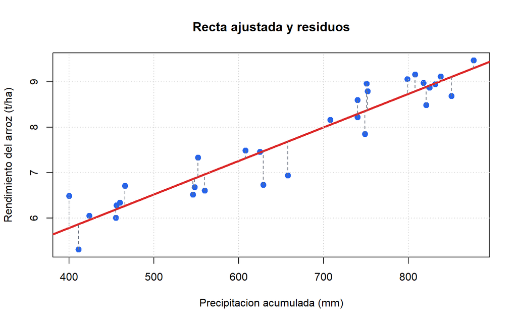

```r
plot(
  rendimiento ~ precipitacion,
  data = datos,
  pch  = 19,
  col  = "#2563eb",
  cex  = 1.2,
  xlab = "Precipitacion acumulada (mm)",
  ylab = "Rendimiento del arroz (t/ha)",
  main = "Recta ajustada y residuos"
)
abline(modelo, col = "#dc2626", lwd = 3)
segments(
  x0  = datos$precipitacion, y0 = datos$rendimiento,
  x1  = datos$precipitacion, y1 = datos$y_hat,
  lty = 2, lwd = 1.4, col = "#6b7280"
)
grid()
```

> Las lineas punteadas representan los residuos: la distancia vertical de cada punto observado a la recta ajustada.

## 5. Bondad de ajuste: el coeficiente de determinacion $R^2$

El $R^2$ mide la proporcion de la variabilidad total de $Y$ que es explicada por el modelo:

$$R^2 = 1 - \frac{SCR}{SCT} =
\frac{SCM}{SCT}$$

| Cantidad | Formula | Significado |
| --- | --- | --- |
| $SCT$ | $\sum(y_i - \bar{y})^2$ | Variabilidad total en $Y$ |
| $SCR$ | $\sum(y_i - \hat{y}_i)^2$ | Variabilidad no explicada (residual) |
| $SCM$ | $\sum(\hat{y}_i - \bar{y})^2$ | Variabilidad explicada por el modelo |

```r
SCT <- sum((datos$rendimiento - mean(datos$rendimiento))^2)
SCR <- sum(datos$residuo^2)
SCM <- sum((datos$y_hat - mean(datos$rendimiento))^2)

cat("SCT =", round(SCT, 4), "\n")
```

```
## SCT = 42.3582
```

```r
cat("SCR =", round(SCR, 4), "\n")
```

```
## SCR = 4.1778
```

```r
cat("SCM =", round(SCM, 4), "\n")
```

```
## SCM = 38.1804
```

```r
cat("SCM + SCR =", round(SCM + SCR, 4), " (debe coincidir con SCT)\n\n")
```

```
## SCM + SCR = 42.3582  (debe coincidir con SCT)
```

```r
R2_manual <- 1 - SCR / SCT
R2_lm     <- summary(modelo)$r.squared

cat("R^2 (manual) =", round(R2_manual, 4), "\n")
```

```
## R^2 (manual) = 0.9014
```

```r
cat("R^2 (lm)     =", round(R2_lm,     4), "\n")
```

```
## R^2 (lm)     = 0.9014
```

```r
cat("\nEl modelo explica el", round(R2_lm * 100, 2),
    "% de la variabilidad del rendimiento.\n")
```

```
##
## El modelo explica el 90.14 % de la variabilidad del rendimiento.
```

> **Alerta:** un $R^2$ alto no garantiza que los supuestos del modelo se cumplan. Siempre debe acompanarse con el diagnostico de residuos.

## 6. Inferencia sobre los coeficientes

### 6.1 Resumen completo del modelo

```r
summary(modelo)
```

```
##
## Call:
## lm(formula = rendimiento ~ precipitacion, data = datos)
##
## Residuals:
##      Min       1Q   Median       3Q      Max
## -0.74544 -0.30334  0.08689  0.27577  0.70682
##
## Coefficients:
##                Estimate Std. Error t value Pr(>|t|)
## (Intercept)   2.8339374  0.3108820   9.116 7.13e-10 ***
## precipitacion 0.0073731  0.0004609  15.997 1.29e-15 ***
## ---
## Signif. codes:  0 '***' 0.001 '**' 0.01 '*' 0.05 '.' 0.1 ' ' 1
##
## Residual standard error: 0.3863 on 28 degrees of freedom
## Multiple R-squared:  0.9014, Adjusted R-squared:  0.8978
## F-statistic: 255.9 on 1 and 28 DF,  p-value: 1.293e-15
```

El resumen reporta:

- **Coefficients:** estimaciones $b_0$, $b_1$, errores estandar, estadistico $t$ y valor $p$.
- **Residual standard error:** estimacion de $\sigma$.
- **Multiple R-squared:** $R^2$.
- **F-statistic:** prueba global de significancia del modelo.

### 6.2 Prueba de hipotesis sobre la pendiente

La prueba evalua si la variable explicativa tiene un efecto lineal significativo sobre la variable respuesta:

$$H_0: \beta_1 = 0 \quad \text{vs} \quad
H_1: \beta_1 \neq 0$$

El estadistico de prueba es:

$$t = \frac{b_1}{SE(b_1)}$$

Se rechaza $H_0$ cuando el valor $p < 0.05$, lo que indica que existe una relacion lineal significativa entre $X$ e $Y$.

```r
tabla_coef <- as.data.frame(summary(modelo)$coefficients)
names(tabla_coef) <- c("Estimado", "Error_std", "t_valor", "p_valor")
tabla_coef[, 1:4]   <- round(tabla_coef[, 1:4], 6)
tabla_coef$Decision <- ifelse(tabla_coef$p_valor < 0.05, "Rechazar H0", "No rechazar H0")
mostrar_tabla(tabla_coef, caption = "Prueba de hipotesis sobre los coeficientes")
```

Prueba de hipotesis sobre los coeficientes

|  | Estimado | Error_std | t_valor | p_valor | Decision |
| --- | --- | --- | --- | --- | --- |
| (Intercept) | 2.833937 | 0.310882 | 9.115799 | 0 | Rechazar H0 |
| precipitacion | 0.007373 | 0.000461 | 15.996567 | 0 | Rechazar H0 |

### 6.3 Intervalos de confianza para los coeficientes

```r
confint(modelo, level = 0.95)
```

```
##                     2.5 %      97.5 %
## (Intercept)   2.197124581 3.470750195
## precipitacion 0.006428962 0.008317258
```

> Un IC del 95% para $\beta_1$ que **no contenga el cero** confirma que la pendiente es estadisticamente significativa.

## 7. Visualizacion de la recta ajustada

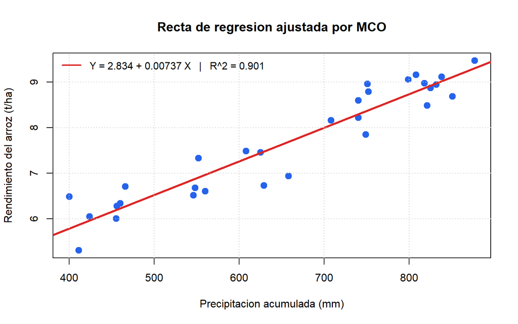

```r
r2_val <- summary(modelo)$r.squared

plot(
  rendimiento ~ precipitacion,
  data = datos,
  pch  = 19,
  col  = "#2563eb",
  cex  = 1.3,
  xlab = "Precipitacion acumulada (mm)",
  ylab = "Rendimiento del arroz (t/ha)",
  main = "Recta de regresion ajustada por MCO"
)
abline(modelo, col = "#dc2626", lwd = 3)
grid()
legend(
  "topleft",
  legend = paste0("Y = ", round(b0, 3), " + ", round(b1, 5), " X",
                  "   |   R^2 = ", round(r2_val, 3)),
  col = "#dc2626", lwd = 2, bty = "n", cex = 0.95
)
```

## 8. Diagnostico de supuestos

Para que las estimaciones MCO sean confiables, el modelo debe satisfacer:

| Supuesto | Descripcion | Herramienta grafica | Prueba estadistica |
| --- | --- | --- | --- |
| Linealidad | $E(Y\\|X) = \beta_0 + \beta_1 X$ | Residuos vs Ajustados | — |
| Independencia | Los $e_i$ son independientes | — | Durbin-Watson |
| Homocedasticidad | $\text{Var}(e_i) = \sigma^2$ constante | Scale-Location | Breusch-Pagan |
| Normalidad | $e_i \sim N(0, \sigma^2)$ | Q-Q plot | Shapiro-Wilk |

### 8.1 Graficos de diagnostico

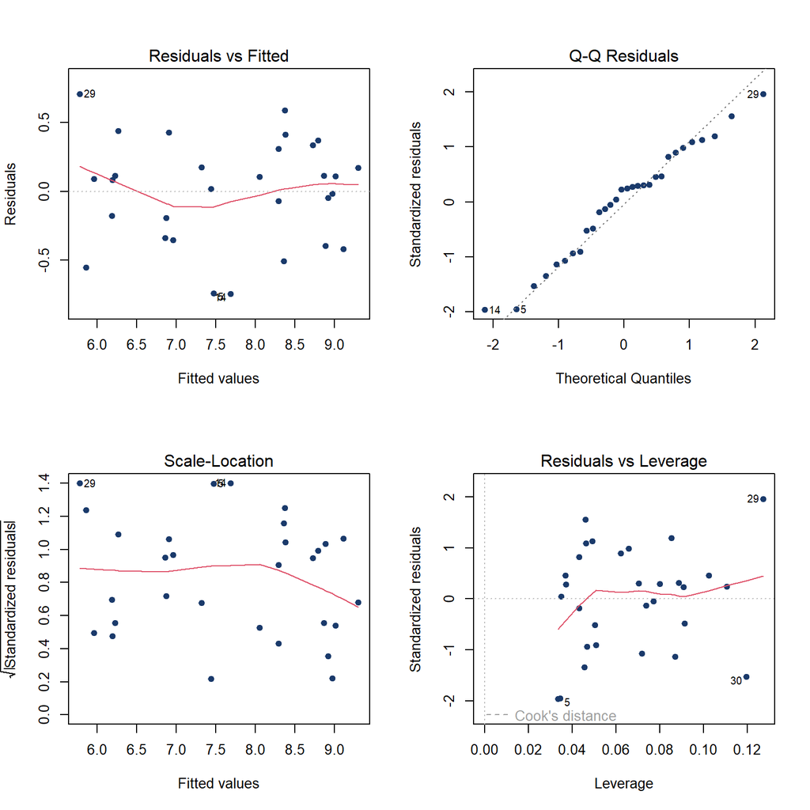

```r
par(mfrow = c(2, 2))
plot(modelo, col = "#1a3a6b", pch = 19, cex = 0.9)
```

```r
par(mfrow = c(1, 1))
```

- **Residuals vs Fitted:** puntos distribuidos aleatoriamente alrededor de cero indican linealidad y homocedasticidad.
- **Normal Q-Q:** los puntos deben seguir la diagonal. Desviaciones indican falta de normalidad.
- **Scale-Location:** la dispersion debe mantenerse constante a lo largo de los valores ajustados.
- **Residuals vs Leverage:** identifica observaciones influyentes mediante la distancia de Cook.

### 8.2 Prueba de Shapiro-Wilk (normalidad)

La prueba contrasta:

$$H_0: \text{los residuos provienen de una
distribucion normal} \quad \text{vs} \quad H_1: \text{no provienen de
una distribucion normal}$$

```r
sw <- shapiro.test(residuals(modelo))
cat("Estadistico W =", round(sw$statistic, 4), "\n")
```

```
## Estadistico W = 0.9706
```

```r
cat("Valor p       =", round(sw$p.value,   4), "\n")
```

```
## Valor p       = 0.5545
```

```r
cat(ifelse(sw$p.value > 0.05,
    "No se rechaza H0: los residuos son compatibles con normalidad.",
    "Se rechaza H0: los residuos no siguen una distribucion normal."), "\n")
```

```
## No se rechaza H0: los residuos son compatibles con normalidad.
```

> **Interpretacion:** el valor $p > 0.05$, por lo tanto **no se rechaza $H_0$**. Los residuos siguen una distribucion aproximadamente normal. El supuesto de normalidad **se cumple**.

### 8.3 Prueba de Breusch-Pagan (homocedasticidad)

La prueba contrasta:

$$H_0: \text{la varianza de los errores es
constante} \quad \text{vs} \quad H_1: \text{la varianza no es constante
(heterocedasticidad)}$$

```r
library(lmtest)
bp <- bptest(modelo)
print(bp)
```

```
##
##  studentized Breusch-Pagan test
##
## data:  modelo
## BP = 0.8987, df = 1, p-value = 0.3431
```

```r
cat(ifelse(bp$p.value > 0.05,
    "No se rechaza H0: varianza constante (homocedasticidad).",
    "Se rechaza H0: hay evidencia de heterocedasticidad."), "\n")
```

```
## No se rechaza H0: varianza constante (homocedasticidad).
```

> **Interpretacion:** el valor $p > 0.05$, por lo tanto **no se rechaza $H_0$**. La varianza de los errores es constante a lo largo de los valores de $X$. El supuesto de homocedasticidad **se cumple**.

### 8.4 Prueba de Durbin-Watson (independencia)

La prueba contrasta:

$$H_0: \text{los residuos son
independientes} \quad \text{vs} \quad H_1: \text{hay autocorrelacion en
los residuos}$$

El estadistico $DW$ toma valores entre 0 y 4; valores cercanos a 2 indican independencia.

```r
dw <- dwtest(modelo)
print(dw)
```

```
##
##  Durbin-Watson test
##
## data:  modelo
## DW = 2.3062, p-value = 0.8039
## alternative hypothesis: true autocorrelation is greater than 0
```

```r
cat(ifelse(dw$p.value > 0.05,
    "No se rechaza H0: los residuos son independientes.",
    "Se rechaza H0: hay autocorrelacion en los residuos."), "\n")
```

```
## No se rechaza H0: los residuos son independientes.
```

> **Interpretacion:** el valor $p > 0.05$, por lo tanto **no se rechaza $H_0$**. Los residuos son independientes entre si. El supuesto de independencia **se cumple**.

### 8.5 Histograma y Q-Q plot de residuos

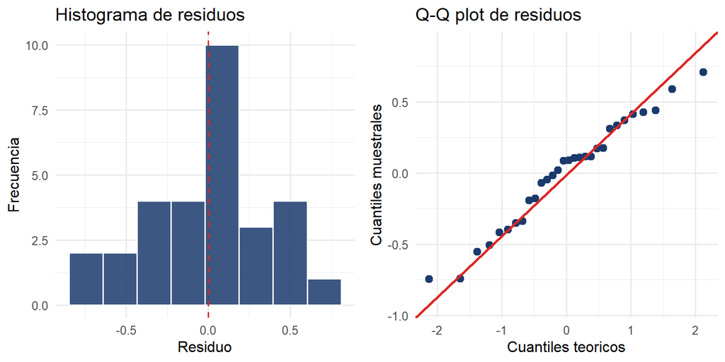

```r
library(ggplot2)

df_res <- data.frame(residuos = residuals(modelo))

p1 <- ggplot(df_res, aes(x = residuos)) +
  geom_histogram(bins = 8, fill = "#1a3a6b", color = "white", alpha = 0.85) +
  geom_vline(xintercept = 0, color = "#dc2626", linetype = "dashed") +
  labs(title = "Histograma de residuos", x = "Residuo", y = "Frecuencia") +
  theme_minimal(base_size = 12)

p2 <- ggplot(df_res, aes(sample = residuos)) +
  stat_qq(color = "#1a3a6b", size = 2.5) +
  stat_qq_line(color = "#dc2626", linewidth = 0.9) +
  labs(title = "Q-Q plot de residuos",
       x = "Cuantiles teoricos", y = "Cuantiles muestrales") +
  theme_minimal(base_size = 12)

gridExtra::grid.arrange(p1, p2, ncol = 2)
```

## 9. Prediccion con `predict()`

Una vez validado el modelo puede usarse para predecir $Y$ para nuevos valores de $X$.

### 9.1 Prediccion puntual

```r
nuevos <- data.frame(precipitacion = c(450, 600, 700, 850))
pred   <- predict(modelo, newdata = nuevos)

resultado <- cbind(nuevos, rendimiento_predicho = round(pred, 3))
mostrar_tabla(resultado, caption = "Predicciones puntuales del rendimiento")
```

Predicciones puntuales del rendimiento

| precipitacion | rendimiento_predicho |
| --- | --- |
| 450 | 6.152 |
| 600 | 7.258 |
| 700 | 7.995 |
| 850 | 9.101 |

### 9.2 Intervalo de confianza vs intervalo de prediccion

Cuando se predice con un modelo de regresion existen dos tipos de intervalos:

**Intervalo de confianza (IC) para la media:**

$$\hat{y} \pm t_{\alpha/2,\, n-2} \cdot
SE(\bar{y}|x^*)$$

Estima el rango donde se encuentra el **valor promedio** de $Y$ para un $X = x^*$ dado. Refleja la incertidumbre sobre la posicion de la recta.

**Intervalo de prediccion (IP) para una observacion individual:**

$$\hat{y} \pm t_{\alpha/2,\, n-2} \cdot
SE(y_\text{nuevo}|x^*)$$

Estima el rango donde caera **una nueva observacion individual** cuando $X = x^*$. Incorpora tanto la incertidumbre del modelo como la variabilidad propia de cada individuo.

> El IP **siempre es mas ancho** que el IC porque predecir una observacion individual es mas incierto que predecir un promedio.

```r
ic <- predict(modelo, newdata = nuevos, interval = "confidence", level = 0.95)
ip <- predict(modelo, newdata = nuevos, interval = "prediction",  level = 0.95)

tabla_pred <- data.frame(
  Precipitacion = nuevos$precipitacion,
  Prediccion    = round(ic[, "fit"], 3),
  IC_inf        = round(ic[, "lwr"], 3),
  IC_sup        = round(ic[, "upr"], 3),
  IP_inf        = round(ip[, "lwr"], 3),
  IP_sup        = round(ip[, "upr"], 3)
)
mostrar_tabla(tabla_pred,
              caption = "IC para la media e IP para observacion individual (95%)")
```

IC para la media e IP para observacion individual (95%)

| Precipitacion | Prediccion | IC_inf | IC_sup | IP_inf | IP_sup |
| --- | --- | --- | --- | --- | --- |
| 450 | 6.152 | 5.909 | 6.395 | 5.324 | 6.980 |
| 600 | 7.258 | 7.104 | 7.412 | 6.452 | 8.064 |
| 700 | 7.995 | 7.845 | 8.145 | 7.190 | 8.800 |
| 850 | 9.101 | 8.868 | 9.334 | 8.276 | 9.926 |

### 9.3 Banda de prediccion sobre el diagrama

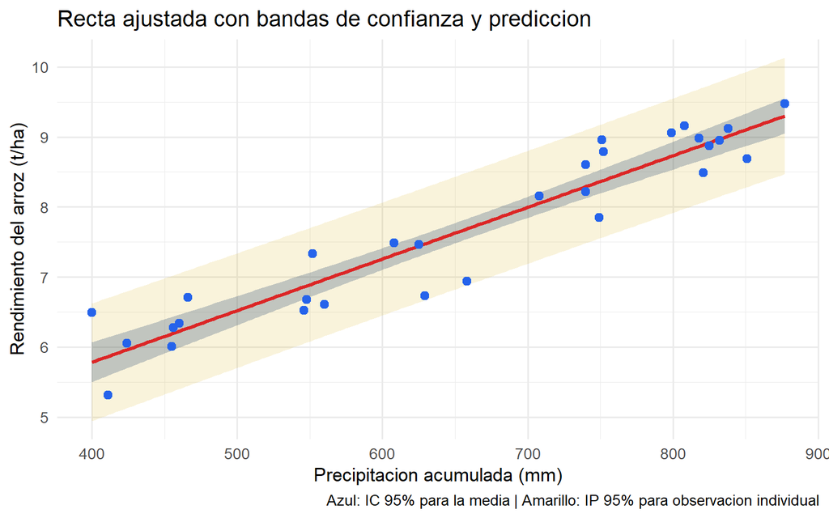

```r
rango_x  <- data.frame(precipitacion = seq(min(datos$precipitacion),
                                           max(datos$precipitacion), length.out = 200))
banda_ic <- as.data.frame(predict(modelo, newdata = rango_x, interval = "confidence"))
banda_ip <- as.data.frame(predict(modelo, newdata = rango_x, interval = "prediction"))

df_bandas <- data.frame(
  x      = rango_x$precipitacion,
  ic_fit = banda_ic$fit,
  ic_lwr = banda_ic$lwr, ic_upr = banda_ic$upr,
  ip_lwr = banda_ip$lwr, ip_upr = banda_ip$upr
)

ggplot() +
  geom_ribbon(data = df_bandas,
              aes(x = x, ymin = ip_lwr, ymax = ip_upr),
              fill = "#d4ac0d", alpha = 0.15) +
  geom_ribbon(data = df_bandas,
              aes(x = x, ymin = ic_lwr, ymax = ic_upr),
              fill = "#1a3a6b", alpha = 0.25) +
  geom_line(data = df_bandas,
            aes(x = x, y = ic_fit),
            color = "#dc2626", linewidth = 1.2) +
  geom_point(data = datos,
             aes(x = precipitacion, y = rendimiento),
             color = "#2563eb", size = 2.5) +
  labs(
    title   = "Recta ajustada con bandas de confianza y prediccion",
    x       = "Precipitacion acumulada (mm)",
    y       = "Rendimiento del arroz (t/ha)",
    caption = "Azul: IC 95% para la media | Amarillo: IP 95% para observacion individual"
  ) +
  theme_minimal(base_size = 13)
```

## 10. Resumen del flujo de trabajo en R

```r
#--- 1. Generar / cargar los datos ---
set.seed(2024)
precipitacion <- round(runif(30, 400, 900), 0)
rendimiento   <- round(2.5 + 0.008 * precipitacion + rnorm(30, 0, 0.4), 2)
datos <- data.frame(precipitacion, rendimiento)

#--- 2. Exploracion ---
summary(datos)
cor(datos$precipitacion, datos$rendimiento)
plot(rendimiento ~ precipitacion, data = datos)

#--- 3. Ajuste del modelo ---
modelo <- lm(rendimiento ~ precipitacion, data = datos)
summary(modelo)
confint(modelo)

#--- 4. Diagnostico de supuestos ---
par(mfrow = c(2, 2))
plot(modelo)

shapiro.test(residuals(modelo))   # Normalidad
library(lmtest)
bptest(modelo)                    # Homocedasticidad
dwtest(modelo)                    # Independencia

#--- 5. Prediccion ---
nuevos <- data.frame(precipitacion = c(450, 600, 700))
predict(modelo, newdata = nuevos)
predict(modelo, newdata = nuevos, interval = "confidence")
predict(modelo, newdata = nuevos, interval = "prediction")
```

# Parte II: Trabajo para Entregar

## Instrucciones generales

El trabajo debe presentarse en formato de **articulo cientifico** con las siguientes secciones obligatorias: portada, introduccion, metodologia, desarrollo, conclusiones y bibliografia. Puede elaborarse en **Word, Google Docs, R Markdown o cualquier procesador de texto** de su preferencia, y debe entregarse en formato **PDF**.

El enfoque del trabajo es el **analisis e interpretacion de resultados**: cada salida de R debe ir acompanada de su correspondiente interpretacion en el contexto del problema. No basta con pegar el output; se debe explicar que significa.

**Fecha de entrega:** segun lo indicado por el docente.  
**Trabajo individual.**

## Contexto del problema

Un grupo de investigadores del sector agropecuario quiere determinar si la **temperatura media diaria durante el ciclo vegetativo** (variable $X$, en °C) tiene un efecto significativo sobre el **rendimiento del cultivo de papa** (variable $Y$, en t/ha). Para ello se registraron datos de 45 lotes experimentales distribuidos en diferentes zonas de produccion.

Los datos se encuentran en el archivo **`datos_papa.csv`** que se entrega junto con este taller. El archivo contiene tres columnas:

| Columna | Descripcion | Unidad |
| --- | --- | --- |
| `lote` | Identificador del lote experimental | — |
| `temperatura_C` | Temperatura media diaria durante el ciclo | °C |
| `rendimiento_tha` | Rendimiento del cultivo de papa | t/ha |

Para cargar los datos en R use:

```r
datos <- read.csv("datos_papa.csv")
```

## Estructura del articulo

### Portada

La portada debe incluir:

- Titulo del trabajo
- Nombre completo del estudiante y codigo
- Nombre del curso y grupo
- Nombre del docente
- Fecha de entrega
- Universidad y facultad

### 1. Introduccion

Redacte un parrafo de introduccion que incluya:

- Importancia del cultivo de papa en Colombia y/o en la region.
- Relacion esperada entre la temperatura y el rendimiento agricola.
- Objetivo del analisis estadistico.
- Breve descripcion de la metodologia que se usara (regresion lineal simple por MCO).

### 2. Metodologia

Describa brevemente:

- El modelo estadistico utilizado: $Y_i = \beta_0 + \beta_1 X_i + e_i$.
- El metodo de estimacion (MCO) y su criterio de minimizacion.
- Las herramientas de R empleadas.
- Los supuestos del modelo y las pruebas estadisticas usadas para verificarlos.

### 3. Desarrollo

Esta es la seccion principal. Debe incluir codigo R, resultados y su interpretacion para cada uno de los siguientes puntos:

#### 3.1 Carga y exploracion de los datos

Cargue el archivo `datos_papa.csv`, presente las estadisticas descriptivas y el diagrama de dispersion. Calcule la correlacion de Pearson e interprete su valor en el contexto del problema.

**Preguntas:**

1. Describa la relacion entre la temperatura y el rendimiento a partir del diagrama de dispersion. La relacion parece lineal?
2. El valor de la correlacion indica una relacion fuerte o debil? Positiva o negativa?

#### 3.2 Estimacion del modelo por MCO

Construya la tabla auxiliar con las columnas $(X_i - \bar{X})$, $(Y_i - \bar{Y})$, $(X_i - \bar{X})(Y_i - \bar{Y})$ y $(X_i - \bar{X})^2$. Calcule $b_0$ y $b_1$ usando las formulas MCO y verifique con `lm()`.

**Preguntas:**

1. Escriba la ecuacion de la recta estimada con cuatro decimales.
2. Interprete el intercepto $b_0$ en el contexto del problema.
3. Interprete la pendiente $b_1$ en el contexto del problema.

#### 3.3 Bondad de ajuste

Calcule manualmente $SCT$, $SCR$ y $SCM$. Verifique que $SCT = SCM + SCR$. Obtenga el $R^2$ manualmente y compare con `summary()`.

**Preguntas:**

1. Que porcentaje de la variabilidad del rendimiento es explicado por la temperatura?
2. El valor de $R^2$ indica un buen ajuste del modelo?

#### 3.4 Inferencia sobre los coeficientes

Use `summary()` y `confint()` para obtener las pruebas de hipotesis e intervalos de confianza.

**Preguntas:**

1. La pendiente $\beta_1$ es estadisticamente significativa al nivel del 5%? Justifique con el valor $p$.
2. El intervalo de confianza al 95% para $\beta_1$ contiene el cero? Que implica esto?
3. Cual es la conclusion sobre la relacion entre temperatura y rendimiento?

#### 3.5 Validacion de supuestos

Presente los cuatro graficos de diagnostico (`plot(modelo)`) y aplique las tres pruebas estadisticas.

**Preguntas:**

1. **Normalidad:** reporte el estadistico $W$ y el valor $p$ de la prueba de Shapiro-Wilk. Se rechaza $H_0$? El supuesto se cumple?
2. **Homocedasticidad:** reporte el valor $p$ de la prueba de Breusch-Pagan. Se rechaza $H_0$? El supuesto se cumple?
3. **Independencia:** reporte el estadistico $DW$ y el valor $p$. Se rechaza $H_0$? El supuesto se cumple?
4. A partir de los graficos y las pruebas, el modelo es valido para realizar inferencias?

#### 3.6 Prediccion

Use `predict()` para predecir el rendimiento para temperaturas de **12 °C**, **18 °C** y **23 °C**. Reporte el IC y el IP al 95% para cada caso.

**Preguntas:**

1. Para una temperatura de 18 °C, cual es el rendimiento esperado?
2. Por que el intervalo de prediccion es mas ancho que el intervalo de confianza?
3. Un productor reporta una temperatura promedio de 30 °C en su lote. Seria apropiado usar este modelo para predecir su rendimiento? Justifique.

### 4. Conclusiones

Redacte un parrafo de conclusiones que sintetice:

- Si existe relacion lineal significativa entre temperatura y rendimiento.
- La magnitud e interpretacion de los coeficientes.
- El ajuste del modelo ($R^2$) y su implicacion practica.
- El cumplimiento de los supuestos y la validez del modelo.
- Una recomendacion practica para los productores de papa basada en los resultados.

### 5. Bibliografia

Toda fuente consultada debe citarse: libros, articulos, paginas web o documentacion de R. Use formato APA.

Ejemplos:

> Montgomery, D. C., Peck, E. A., & Vining, G. G. (2012). *Introduction to Linear Regression Analysis* (5th ed.). Wiley.

> R Core Team (2024). *R: A Language and Environment for Statistical Computing*. R Foundation for Statistical Computing. https://www.R-project.org/

> Nombre del autor o sitio (ano). *Titulo de la pagina o articulo*. Recuperado de: [URL completa]

## Criterios de evaluacion

| Criterio | Puntaje |
| --- | --- |
| Portada completa | 0.5 |
| Introduccion con contexto y objetivo claro | 1.0 |
| Metodologia bien descrita | 0.5 |
| Estimacion MCO manual y con `lm()` correcta | 1.5 |
| Interpretacion de coeficientes y $R^2$ | 1.5 |
| Validacion de supuestos con pruebas e interpretacion | 2.0 |
| Prediccion con IC e IP interpretados | 1.5 |
| Conclusiones pertinentes | 1.0 |
| Bibliografia de fuentes consultadas | 0.5 |
| **Total** | **10.0** |